# Step 1 Simulate and visualize Golimumab monkey PK study designs

Author

NAMLink

# Purpose

This tutorial creates virtual monkey concentration-time profiles from the uncalibrated, a priori PBPK models prepared in `02_APriori_PBPK_Workflow`. It is the data-generation step for exploring reduced monkey PK study designs.

**Golimumab** is used as the worked example. In the completed 02_APriori_PBPK_Workflow monkey evaluation, its predicted Cmax, AUC0-28d, and clearance were all within two-fold of the observed values, and it had the smallest average absolute log-fold error across those endpoints. The script does not fit the model to monkey PK data. It combines a 50-animal monkey physiology population with uncertainty in six molecule-specific PBPK inputs, then simulates various doses for the candidate study designs.

# What this tutorial varies

The following configured Golimumab inputs are varied independently:

1. FcRn binding affinity, `Kd (FcRn) in endosomal space`;
2. drug-target binding affinity, `Kd`;
3. drug-target dissociation rate, `koff`;
4. drug-target complex internalization rate, `kint`;
5. target degradation rate, `kdeg`; and
6. target reference concentration.

Two variability scenarios are evaluated: 30% and 50% coefficient of variation (CV). One hundred parameter sets are drawn at each variability level. Positive parameter values are drawn from lognormal distributions. The lognormal mean is adjusted so that the arithmetic mean of each distribution equals the configured a priori input. This prevents a larger CV from shifting the mean solely because of the lognormal transformation.

The 100 parameter sets are crossed with the same 50 physiological monkeys. This creates 5,000 distinct physiology-parameter combinations per variability level. Each combination is requested at all five doses, for a nominal total of 50,000 concentration-time profiles before sparse sampling. Any persistent PK-Sim failure is explicitly documented and excluded. The parameter draws are independent and represent a deliberately simple uncertainty scenario. They should be replaced by evidence-based distributions and correlations when those data are available.

```r
rm(list = ls())

suppressPackageStartupMessages({
  library(dplyr)
  library(esqlabsR)
  library(ggplot2)
  library(knitr)
  library(ospsuite)
  library(purrr)
  library(readr)
  library(scales)
  library(tibble)
  library(tidyr)
})

find_project_root <- function(start = getwd()) {
  current <- normalizePath(start, winslash = "/", mustWork = TRUE)
  repeat {
    required <- c(
      file.path(current, "01_Models"),
      file.path(current, "02_APriori_PBPK_Workflow"),
      file.path(current, "03_Study_Simulations")
    )
    if (all(dir.exists(required))) return(current)
    parent <- dirname(current)
    if (identical(parent, current)) {
      stop("Could not locate the PBPK_mAb_NAM_Tutorial project root.")
    }
    current <- parent
  }
}

assert_files_exist <- function(paths, description = "Required input") {
  missing <- paths[!file.exists(paths)]
  if (length(missing) > 0L) {
    stop(description, " is missing: ", paste(missing, collapse = "; "))
  }
  invisible(paths)
}

PROJECT_ROOT <- find_project_root()
APRIORI_DIR <- file.path(PROJECT_ROOT, "02_APriori_PBPK_Workflow")
STUDY_DIR <- file.path(PROJECT_ROOT, "03_Study_Simulations")
OUTPUT_DIR <- file.path(STUDY_DIR, "SimsOutputs")
PROFILE_DIR <- file.path(OUTPUT_DIR, "SimulationProfiles")
TABLE_DIR <- file.path(OUTPUT_DIR, "Tables")
CHECKPOINT_DIR <- file.path(PROFILE_DIR, "Step1_Checkpoints")

walk(
  c(OUTPUT_DIR, PROFILE_DIR, TABLE_DIR, CHECKPOINT_DIR),
  dir.create,
  recursive = TRUE,
  showWarnings = FALSE
)

set.seed(20260919)

MOLECULES <- "Golimumab"
SOURCE_SCENARIOS <- c(Golimumab = "Golimumab_Monkey_3_mpk")
DOSES_MG_KG <- c(0.1, 1, 3, 10, 30)
VARIABILITY_CV <- c(0.30, 0.50)
N_PARAMETER_SETS <- as.integer(Sys.getenv(
  "PBPK_TUTORIAL_N_PARAMETER_SETS",
  unset = "100"
))
if (!is.finite(N_PARAMETER_SETS) || N_PARAMETER_SETS < 2L) {
  stop("N_PARAMETER_SETS must be an integer of at least 2.")
}
N_POPULATION_ANIMALS <- 50L
POPULATION_NAME <- "Monkey"
POPULATION_SEED <- 20260919L

# Run a limited number of parameter sets at a time. Each parameter set is
# crossed with all 50 monkeys, so the default batch contains 500 profiles.
# Completed batches are checkpointed and reused when the document is rerun.
N_PARAMETER_SETS_PER_BATCH <- as.integer(Sys.getenv(
  "PBPK_TUTORIAL_PARAMETER_SETS_PER_BATCH",
  unset = "10"
))
if (!is.finite(N_PARAMETER_SETS_PER_BATCH) ||
    N_PARAMETER_SETS_PER_BATCH < 1L) {
  stop("N_PARAMETER_SETS_PER_BATCH must be a positive integer.")
}

FORCE_RERUN <- tolower(Sys.getenv(
  "PBPK_TUTORIAL_FORCE_RERUN",
  unset = "false"
)) %in% c("true", "1", "yes")

# One fixed sampling schedule is used in every candidate design.
SPARSE_TIME_H <- sort(unique(
  c(0.25, 1, 2, 4, 8, 1, 2, 6, 10, 14, 21, 28) *
    c(rep(1, 5), rep(24, 7))
))
SAMPLING_TIME_H <- SPARSE_TIME_H

MAB_PLASMA_OUTPUT_PATH <-
  "Organism|PeripheralVenousBlood|mAb|Plasma (Peripheral Venous Blood)"

PARAMETER_PATHS <- c(
  `Kd (FcRn)` = "mAb|Kd (FcRn) in endosomal space",
  `Target Kd` = "mAb-Target-InVitro|Kd",
  koff = "mAb-Target-InVitro|koff",
  kint = "Complex Internalization|kint",
  kdeg = "Target degradation|kdeg",
  `Target reference concentration` = "Target|Reference concentration"
)

DOSE_PATH <-
  "Events|IV_Bolus|Application_1|ProtocolSchemaItem|DosePerBodyWeight"

PROJECT_CONFIG_FILE <- file.path(APRIORI_DIR, "ProjectConfiguration.xlsx")
POPULATION_CONFIG_FILE <- file.path(
  APRIORI_DIR, "Configurations", "Populations.xlsx"
)
MONKEY_DATA_FILE <- file.path(PROJECT_ROOT, "00_Data", "Monkey", "mAb_data_clean.csv")
OUTPUT_RDS <- file.path(
  PROFILE_DIR,
  "golimumab_monkey_population_uncertainty_profiles.rds"
)
PARAMETER_DRAW_FILE <- file.path(
  TABLE_DIR,
  "golimumab_monkey_parameter_sets.csv"
)
SETTINGS_FILE <- file.path(
  TABLE_DIR,
  "golimumab_monkey_simulation_settings.csv"
)
BASE_POPULATION_FILE <- file.path(
  TABLE_DIR,
  "golimumab_base_monkey_population.csv"
)
PROFILE_INDEX_FILE <- file.path(
  TABLE_DIR,
  "golimumab_crossed_profile_index.csv"
)
FAILED_PROFILE_FILE <- file.path(
  TABLE_DIR,
  "golimumab_failed_simulation_profiles.csv"
)

assert_files_exist(
  c(PROJECT_CONFIG_FILE, POPULATION_CONFIG_FILE, MONKEY_DATA_FILE),
  "A priori PBPK workflow input"
)

package_record <- tibble(
  Package = c("R", "esqlabsR", "ospsuite"),
  Version = c(
    paste(R.version$major, R.version$minor, sep = "."),
    as.character(packageVersion("esqlabsR")),
    as.character(packageVersion("ospsuite"))
  )
)

package_record |>
  kable(caption = "Software versions recorded for the simulation run")
```

Software versions recorded for the simulation run

| Package | Version |
| --- | --- |
| R | 4.6.1 |
| esqlabsR | 5.7.0 |
| ospsuite | 12.4.3 |

# Step 1 Read molecular weights

Concentrations returned by the PBPK models are in micromol/L. Molecular weight is read from the prepared monkey dataset and used to convert concentrations to microgram/mL.

```r
mw_lookup <- read_csv(
  MONKEY_DATA_FILE,
  show_col_types = FALSE,
  locale = locale(encoding = "UTF-8")
) |>
  transmute(
    Molecule = as.character(.data$Molecule),
    MW_g_mol = as.numeric(.data$Molecular.Weight)
  ) |>
  filter(.data$Molecule %in% MOLECULES) |>
  group_by(.data$Molecule) |>
  summarise(
    MW_g_mol = median(.data$MW_g_mol, na.rm = TRUE),
    .groups = "drop"
  )

if (!setequal(mw_lookup$Molecule, MOLECULES) ||
    any(!is.finite(mw_lookup$MW_g_mol)) ||
    any(mw_lookup$MW_g_mol <= 0)) {
  stop("A unique positive molecular weight was not found for each molecule.")
}

mw_lookup |>
  kable(digits = 1, caption = "Molecular weights used for unit conversion")
```

Molecular weights used for unit conversion

| Molecule | MW_g_mol |
| --- | --- |
| Golimumab | 150000 |

# Step 2 Load the completed a priori Golimumab scenario

The 3 mg/kg monkey scenario is used only as a fully parameterized model template. The script later changes the dose to each value in the five-dose grid. No observed PK data enter this step.

```r
project_configuration <- createProjectConfiguration(
  path = PROJECT_CONFIG_FILE,
  ignoreVersionCheck = TRUE
)

scenario_configurations <- readScenarioConfigurationFromExcel(
  scenarioNames = unname(SOURCE_SCENARIOS),
  projectConfiguration = project_configuration
)

scenarios <- createScenarios(
  scenarioConfigurations = scenario_configurations
)

if (!setequal(names(scenarios), unname(SOURCE_SCENARIOS))) {
  stop("The requested a priori monkey scenarios were not created.")
}

tibble(
  Molecule = names(SOURCE_SCENARIOS),
  Source_scenario = unname(SOURCE_SCENARIOS),
  Role = "Concordant Objective 1 example"
) |>
  kable(caption = "A priori PBPK scenarios used as simulation templates")
```

A priori PBPK scenarios used as simulation templates

| Molecule | Source_scenario | Role |
| --- | --- | --- |
| Golimumab | Golimumab_Monkey_3_mpk | Concordant Objective 1 example |

# Step 3 Generate the 50-monkey physiological population

`Populations.xlsx` defines the Monkey population with 50 individuals, equal probabilities of female and male animals, and a body-weight range of 3-7 kg. The script reads that configuration through `esqlabsR`, supplies a fixed PK-Sim population seed, and generates the population once. The same 50 physiological animals are then reused for both uncertainty levels and all five doses.

Using a fixed seed is important here. Without it, PK-Sim would generate a new population each time the document is rendered, making changes between runs harder to interpret.

```r
population_characteristics <- readPopulationCharacteristicsFromXLS(
  XLSpath = POPULATION_CONFIG_FILE,
  populationName = POPULATION_NAME,
  sheet = "Demographics"
)

if (population_characteristics$numberOfIndividuals !=
    N_POPULATION_ANIMALS) {
  stop(
    "The Monkey row in Populations.xlsx must define ",
    N_POPULATION_ANIMALS, " individuals."
  )
}

population_characteristics$seed <- POPULATION_SEED
population_result <- createPopulation(
  populationCharacteristics = population_characteristics
)
base_population <- population_result$population
base_population_table <- populationToDataFrame(base_population)

if (base_population$count != N_POPULATION_ANIMALS ||
    nrow(base_population_table) != N_POPULATION_ANIMALS) {
  stop("The generated monkey population does not contain 50 individuals.")
}

write_csv(base_population_table, BASE_POPULATION_FILE)

weight_column <- grep(
  "^Organism\\|Weight( \\[kg\\])?$",
  names(base_population_table),
  value = TRUE
)
if (length(weight_column) != 1L) {
  stop("The generated population must contain one organism-weight column.")
}

tibble(
  Population = POPULATION_NAME,
  Animals = base_population$count,
  Seed_requested = POPULATION_SEED,
  Seed_used = population_result$seed,
  Weight_min_kg = min(base_population_table[[weight_column]]),
  Weight_max_kg = max(base_population_table[[weight_column]])
) |>
  kable(
    digits = 3,
    caption = "Generated physiological monkey population"
  )
```

Generated physiological monkey population

| Population | Animals | Seed_requested | Seed_used | Weight_min_kg | Weight_max_kg |
| --- | --- | --- | --- | --- | --- |
| Monkey | 50 | 20260919 | 20260919 | 3.094 | 6.944 |

# Step 4 Verify parameter and dose paths

The path strings below must identify exactly one non-formula parameter in each model. The script stops rather than guessing when a model path changes.

```r
inspect_scenario_inputs <- function(molecule) {
  scenario_name <- unname(SOURCE_SCENARIOS[[molecule]])
  simulation <- scenarios[[scenario_name]]$simulation
  all_paths <- c(PARAMETER_PATHS, `Dose per body weight` = DOSE_PATH)

  map_dfr(names(all_paths), function(label) {
    path <- unname(all_paths[[label]])
    matches <- getAllParametersMatching(
      paths = path,
      container = simulation
    )
    if (length(matches) != 1L) {
      stop(
        "Expected one match for ", label, " in ", molecule,
        "; found ", length(matches), "."
      )
    }
    if (isExplicitFormulaByPath(path = path, simulation = simulation)) {
      stop(label, " is formula-defined in ", molecule, ".")
    }
    value <- getQuantityValuesByPath(
      quantityPaths = path,
      simulation = simulation
    )
    if (length(value) != 1L || !is.finite(value) || value <= 0) {
      stop("Expected one positive finite value for ", label, " in ", molecule)
    }
    tibble(
      Molecule = molecule,
      Input = label,
      Path = path,
      Configured_value_internal = as.numeric(value),
      Display_unit = as.character(matches[[1]]$unit)
    )
  })
}

configured_inputs <- map_dfr(MOLECULES, inspect_scenario_inputs)

configured_inputs |>
  mutate(Configured_value_internal = signif(.data$Configured_value_internal, 5)) |>
  kable(caption = "Validated model inputs before uncertainty is added")
```

Validated model inputs before uncertainty is added

| Molecule | Input | Path | Configured_value_internal | Display_unit |
| --- | --- | --- | --- | --- |
| Golimumab | Kd (FcRn) | mAb\|Kd (FcRn) in endosomal space | 1.0700000 | µmol/l |
| Golimumab | Target Kd | mAb-Target-InVitro\|Kd | 0.0000180 | µmol/l |
| Golimumab | koff | mAb-Target-InVitro\|koff | 0.0055830 | 1/min |
| Golimumab | kint | Complex Internalization\|kint | 0.0144330 | 1/min |
| Golimumab | kdeg | Target degradation\|kdeg | 0.0037167 | 1/min |
| Golimumab | Target reference concentration | Target\|Reference concentration | 0.0000010 | µmol/l |
| Golimumab | Dose per body weight | Events\|IV_Bolus\|Application_1\|ProtocolSchemaItem\|DosePerBodyWeight | 0.0000030 | kg/kg |

# Step 5 Draw 100 positive PBPK parameter sets

The function uses the standard relationship between lognormal CV and log-scale standard deviation. Subtracting half the log-scale variance from `log(mean)` keeps the arithmetic mean at the configured value.

```r
draw_lognormal_mean_cv <- function(n, arithmetic_mean, cv) {
  if (!is.finite(arithmetic_mean) || arithmetic_mean <= 0) {
    stop("A lognormal arithmetic mean must be positive and finite.")
  }
  if (!is.finite(cv) || cv < 0) stop("CV must be non-negative and finite.")
  sdlog <- sqrt(log1p(cv^2))
  meanlog <- log(arithmetic_mean) - 0.5 * sdlog^2
  rlnorm(n, meanlog = meanlog, sdlog = sdlog)
}

parameter_baseline <- configured_inputs |>
  filter(.data$Input %in% names(PARAMETER_PATHS)) |>
  select(
    .data$Molecule,
    Parameter = .data$Input,
    Typical_value_internal = .data$Configured_value_internal,
    .data$Display_unit
  )

parameter_draws_long <- crossing(
  Molecule = MOLECULES,
  Variability_CV = VARIABILITY_CV,
  ParameterSetId = seq_len(N_PARAMETER_SETS)
) |>
  left_join(parameter_baseline, by = "Molecule") |>
  group_by(.data$Molecule, .data$Variability_CV, .data$Parameter) |>
  mutate(
    Parameter_value_internal = draw_lognormal_mean_cv(
      n(),
      first(.data$Typical_value_internal),
      first(.data$Variability_CV)
    )
  ) |>
  ungroup()

parameter_draws <- parameter_draws_long |>
  select(
    .data$Molecule, .data$Variability_CV, .data$ParameterSetId,
    .data$Parameter, .data$Parameter_value_internal
  ) |>
  pivot_wider(
    names_from = .data$Parameter,
    values_from = .data$Parameter_value_internal
  ) |>
  arrange(
    .data$Molecule, .data$Variability_CV, .data$ParameterSetId
  )

draw_check <- parameter_draws_long |>
  group_by(
    .data$Molecule, .data$Variability_CV, .data$Parameter,
    .data$Typical_value_internal, .data$Display_unit
  ) |>
  summarise(
    Draw_mean = mean(.data$Parameter_value_internal),
    Draw_CV = sd(.data$Parameter_value_internal) /
      mean(.data$Parameter_value_internal),
    .groups = "drop"
  ) |>
  mutate(
    Mean_to_configured_ratio = .data$Draw_mean /
      .data$Typical_value_internal
  )

draw_check |>
  mutate(
    across(
      c(
        .data$Typical_value_internal, .data$Draw_mean,
        .data$Draw_CV, .data$Mean_to_configured_ratio
      ),
      ~ signif(.x, 4)
    )
  ) |>
  kable(caption = "Realized parameter-draw distributions")
```

Realized parameter-draw distributions

| Molecule | Variability_CV | Parameter | Typical_value_internal | Display_unit | Draw_mean | Draw_CV | Mean_to_configured_ratio |
| --- | --- | --- | --- | --- | --- | --- | --- |
| Golimumab | 0.3 | Kd (FcRn) | 1.070000 | µmol/l | 1.1260000 | 0.3162 | 1.0520 |
| Golimumab | 0.3 | Target Kd | 0.000018 | µmol/l | 0.0000180 | 0.2590 | 0.9996 |
| Golimumab | 0.3 | Target reference concentration | 0.000001 | µmol/l | 0.0000010 | 0.2648 | 1.0040 |
| Golimumab | 0.3 | kdeg | 0.003717 | 1/min | 0.0037260 | 0.3285 | 1.0030 |
| Golimumab | 0.3 | kint | 0.014430 | 1/min | 0.0144200 | 0.2857 | 0.9990 |
| Golimumab | 0.3 | koff | 0.005583 | 1/min | 0.0053460 | 0.2900 | 0.9576 |
| Golimumab | 0.5 | Kd (FcRn) | 1.070000 | µmol/l | 0.9943000 | 0.4849 | 0.9293 |
| Golimumab | 0.5 | Target Kd | 0.000018 | µmol/l | 0.0000168 | 0.4190 | 0.9364 |
| Golimumab | 0.5 | Target reference concentration | 0.000001 | µmol/l | 0.0000010 | 0.5426 | 0.9648 |
| Golimumab | 0.5 | kdeg | 0.003717 | 1/min | 0.0037240 | 0.4660 | 1.0020 |
| Golimumab | 0.5 | kint | 0.014430 | 1/min | 0.0144400 | 0.4673 | 1.0010 |
| Golimumab | 0.5 | koff | 0.005583 | 1/min | 0.0051290 | 0.4914 | 0.9187 |

# Step 6 Cross physiology with parameter uncertainty and run the model

At each uncertainty level, the 100 parameter sets are crossed with all 50 physiological monkeys. The resulting population contains 5,000 rows:

`100 Golimumab parameter sets x 50 physiological monkeys = 5,000 profiles`.

The six molecule-specific input values are stored as population parameters. For reliability, the 5,000 combinations are not submitted to PK-Sim as one large job. They are divided into batches of 10 parameter sets crossed with all 50 monkeys (500 profiles per batch). The same crossed population is reused at each dose. This preserves the identity of each physiology-parameter combination across the dose grid while keeping the study design parallel-group when profiles are resampled later.

Every completed batch is immediately saved under `Step1_Checkpoints`. If a render is interrupted, a subsequent render validates and reuses those files before continuing with the first unfinished batch. Set the environment variable `PBPK_TUTORIAL_FORCE_RERUN=true` only when all simulations should be recomputed. A smaller batch can be requested, if needed, through `PBPK_TUTORIAL_PARAMETER_SETS_PER_BATCH`.

If a profile still produces no output after the single-core retries, its identifiers and error are written to `golimumab_failed_simulation_profiles.csv` and that profile is excluded. On a subsequent render, profiles already listed in this file are skipped rather than submitted again. The final inventory reports the resulting profile count for every variability-by-dose cell.

The model runs on its configured time grid. Each full profile is then linearly interpolated to the fixed sparse schedule used throughout this tutorial.

```r
build_crossed_population <- function(variability_cv) {
  cell_draws <- parameter_draws |>
    filter(.data$Variability_CV == variability_cv) |>
    arrange(.data$ParameterSetId)

  if (nrow(cell_draws) != N_PARAMETER_SETS) {
    stop("The parameter-set table is incomplete at CV = ", variability_cv)
  }

  profile_index <- crossing(
    ParameterSetId = cell_draws$ParameterSetId,
    PopulationIndividualId = base_population_table$IndividualId
  ) |>
    arrange(.data$ParameterSetId, .data$PopulationIndividualId) |>
    mutate(
      SimulationIndividualId = seq.int(0L, n() - 1L),
      VirtualProfileId = .data$SimulationIndividualId + 1L,
      Variability_CV = variability_cv,
      .before = 1
    )

  population_rows <- match(
    profile_index$PopulationIndividualId,
    base_population_table$IndividualId
  )
  expanded_table <- base_population_table[
    population_rows,
    ,
    drop = FALSE
  ]
  expanded_table$IndividualId <- profile_index$SimulationIndividualId

  for (parameter_name in names(PARAMETER_PATHS)) {
    values_by_set <- setNames(
      cell_draws[[parameter_name]],
      cell_draws$ParameterSetId
    )
    expanded_table[[PARAMETER_PATHS[[parameter_name]]]] <- unname(
      values_by_set[as.character(profile_index$ParameterSetId)]
    )
  }

  crossed_population <- populationFromDataFrame(expanded_table)
  expected_count <- N_PARAMETER_SETS * N_POPULATION_ANIMALS
  if (crossed_population$count != expected_count) {
    stop("The crossed population does not contain ", expected_count, " rows.")
  }

  list(
    population = crossed_population,
    index = profile_index,
    table = expanded_table
  )
}

crossed_populations <- setNames(
  map(VARIABILITY_CV, build_crossed_population),
  as.character(VARIABILITY_CV)
)

crossed_profile_index <- map_dfr(
  crossed_populations,
  "index",
  .id = "Variability_key"
) |>
  select(-.data$Variability_key)

write_csv(crossed_profile_index, PROFILE_INDEX_FILE)

crossed_profile_index |>
  count(.data$Variability_CV, name = "Physiology_parameter_combinations") |>
  mutate(`Variability CV (%)` = 100 * .data$Variability_CV) |>
  select(`Variability CV (%)`, .data$Physiology_parameter_combinations) |>
  kable(caption = "Crossed simulation populations")
```

Crossed simulation populations

| Variability CV (%) | Physiology_parameter_combinations |
| --- | --- |
| 30 | 5000 |
| 50 | 5000 |

```r
interpolate_to_sampling_times <- function(time_h, concentration_umol_l) {
  keep <- is.finite(time_h) & is.finite(concentration_umol_l)
  time_h <- as.numeric(time_h[keep])
  concentration_umol_l <- as.numeric(concentration_umol_l[keep])
  ord <- order(time_h)
  time_h <- time_h[ord]
  concentration_umol_l <- concentration_umol_l[ord]
  if (length(unique(time_h)) < 2L) {
    stop("A simulated profile contains fewer than two distinct times.")
  }
  approx(
    x = time_h,
    y = concentration_umol_l,
    xout = SAMPLING_TIME_H,
    method = "linear",
    rule = 2,
    ties = mean
  )$y
}

scenario_name <- unname(SOURCE_SCENARIOS[["Golimumab"]])
simulation <- scenarios[[scenario_name]]$simulation
old_output_paths <- map_chr(simulation$outputSelections$allOutputs, "path")
clearOutputs(simulation = simulation)
addOutputs(
  quantitiesOrPaths = MAB_PLASMA_OUTPUT_PATH,
  simulation = simulation
)

baseline_dose_internal <- getQuantityValuesByPath(
  quantityPaths = DOSE_PATH,
  simulation = simulation
)
baseline_dose_mg_kg <- 3
mw <- mw_lookup$MW_g_mol[mw_lookup$Molecule == "Golimumab"]

run_options <- SimulationRunOptions$new()
run_options$checkForNegativeValues <- FALSE
detected_cores <- parallel::detectCores(logical = TRUE)
if (!is.finite(detected_cores)) detected_cores <- 2L
run_options$numberOfCores <- min(8L, max(1L, detected_cores - 1L))

simulation_grid <- crossing(
  Variability_CV = VARIABILITY_CV,
  Dose_mg_kg = DOSES_MG_KG
)

run_started <- Sys.time()

make_population_subset <- function(population_bundle, simulation_ids) {
  simulation_ids <- as.integer(simulation_ids)
  subset_index <- population_bundle$index |>
    filter(.data$SimulationIndividualId %in% simulation_ids) |>
    arrange(match(.data$SimulationIndividualId, simulation_ids)) |>
    mutate(BatchIndividualId = seq.int(0L, n() - 1L))

  if (!setequal(subset_index$SimulationIndividualId, simulation_ids)) {
    stop("A requested simulation individual is absent from the population.")
  }

  table_rows <- match(
    subset_index$SimulationIndividualId,
    population_bundle$table$IndividualId
  )
  subset_table <- population_bundle$table[table_rows, , drop = FALSE]
  subset_table$IndividualId <- subset_index$BatchIndividualId

  list(
    population = populationFromDataFrame(subset_table),
    index = subset_index
  )
}

run_population_subset <- function(population_bundle, simulation_ids,
                                  options) {
  subset_bundle <- make_population_subset(
    population_bundle,
    simulation_ids
  )
  results <- runSimulations(
    simulations = simulation,
    population = subset_bundle$population,
    simulationRunOptions = options
  )[[1]]

  output <- getOutputValues(
    simulationResults = results,
    quantitiesOrPaths = MAB_PLASMA_OUTPUT_PATH
  )$data |>
    as_tibble() |>
    transmute(
      BatchIndividualId = as.integer(.data$IndividualId),
      ModelTime_h = as.numeric(.data$Time) / 60,
      Conc_umol_L = as.numeric(.data[[MAB_PLASMA_OUTPUT_PATH]])
    ) |>
    left_join(
      subset_bundle$index |>
        select(.data$BatchIndividualId, .data$SimulationIndividualId),
      by = "BatchIndividualId"
    ) |>
    select(-.data$BatchIndividualId)

  if (any(is.na(output$SimulationIndividualId))) {
    stop("PK-Sim returned an individual identifier not in the submitted batch.")
  }

  rm(results)
  invisible(gc())
  output
}

complete_profile_ids <- function(output) {
  if (nrow(output) == 0L) return(integer())
  output |>
    filter(
      is.finite(.data$ModelTime_h),
      is.finite(.data$Conc_umol_L)
    ) |>
    group_by(.data$SimulationIndividualId) |>
    summarise(
      N_time = n_distinct(.data$ModelTime_h),
      First_time_h = min(.data$ModelTime_h),
      Last_time_h = max(.data$ModelTime_h),
      .groups = "drop"
    ) |>
    filter(
      .data$N_time >= 2L,
      .data$First_time_h <= min(SAMPLING_TIME_H),
      .data$Last_time_h >= max(SAMPLING_TIME_H)
    ) |>
    pull(.data$SimulationIndividualId)
}

retry_options <- SimulationRunOptions$new()
retry_options$checkForNegativeValues <- FALSE
retry_options$numberOfCores <- 1L

run_complete_batch <- function(population_bundle, expected_ids, cv_value,
                               dose_value, batch_number) {
  initial_error <- NULL
  retry_errors <- character()
  output <- tryCatch(
    run_population_subset(population_bundle, expected_ids, run_options),
    error = function(e) {
      initial_error <<- conditionMessage(e)
      tibble(
        SimulationIndividualId = integer(),
        ModelTime_h = numeric(),
        Conc_umol_L = numeric()
      )
    }
  )

  completed_ids <- complete_profile_ids(output)
  missing_ids <- setdiff(expected_ids, completed_ids)

  if (length(missing_ids) == length(expected_ids)) {
    message(
      "  Batch ", batch_number,
      " produced no complete profiles; retrying the complete batch with one core."
    )
    output <- tryCatch(
      run_population_subset(population_bundle, expected_ids, retry_options),
      error = function(e) {
        initial_error <<- paste(
          c(initial_error, "Single-core batch retry", conditionMessage(e)),
          collapse = "; "
        )
        output
      }
    )
    completed_ids <- complete_profile_ids(output)
    missing_ids <- setdiff(expected_ids, completed_ids)
  }

  if (length(missing_ids) > 0L) {
    message(
      "  Batch ", batch_number, " returned ", length(missing_ids),
      " incomplete profile(s); retrying those profiles one at a time ",
      "with one core."
    )

    retry_output <- map_dfr(missing_ids, function(simulation_id) {
      tryCatch(
        run_population_subset(
          population_bundle,
          simulation_id,
          retry_options
        ),
        error = function(e) {
          retry_errors[[as.character(simulation_id)]] <<- conditionMessage(e)
          tibble(
            SimulationIndividualId = integer(),
            ModelTime_h = numeric(),
            Conc_umol_L = numeric()
          )
        }
      )
    })
```

```r
    output <- bind_rows(
      output |> filter(.data$SimulationIndividualId %in% completed_ids),
      retry_output
    ) |>
      distinct(
        .data$SimulationIndividualId,
        .data$ModelTime_h,
        .keep_all = TRUE
      )
  }

  still_missing <- setdiff(expected_ids, complete_profile_ids(output))
  failed_index <- tibble()
  if (length(still_missing) > 0L) {
    fallback_error <- if (is.null(initial_error)) {
      "Incomplete output after single-profile retry"
    } else {
      paste("Initial batch error:", initial_error)
    }
    failed_index <- population_bundle$index |>
      filter(.data$SimulationIndividualId %in% still_missing) |>
      transmute(
        Timestamp = format(Sys.time(), "%Y-%m-%d %H:%M:%S"),
        Variability_CV = cv_value,
        Dose_mg_kg = dose_value,
        Batch = batch_number,
        SimulationIndividualId = .data$SimulationIndividualId,
        VirtualProfileId = .data$VirtualProfileId,
        ParameterSetId = .data$ParameterSetId,
        PopulationIndividualId = .data$PopulationIndividualId,
        Error = unname(retry_errors[
          as.character(.data$SimulationIndividualId)
        ])
      ) |>
      mutate(
        Error = if_else(is.na(.data$Error), fallback_error, .data$Error)
      )
    write_csv(
      failed_index,
      FAILED_PROFILE_FILE,
      append = file.exists(FAILED_PROFILE_FILE)
    )
    message(
      "  Skipping ", length(still_missing),
      " persistently incomplete profile(s) in batch ", batch_number,
      ". Their identifiers were recorded in ", FAILED_PROFILE_FILE, "."
    )
  }

  successful_ids <- intersect(expected_ids, complete_profile_ids(output))
  completed_output <- output |>
    filter(.data$SimulationIndividualId %in% successful_ids)
  attr(completed_output, "failed_profiles") <- failed_index
  completed_output
}

checkpoint_path <- function(cv_value, dose_value, batch_number) {
  file.path(
    CHECKPOINT_DIR,
    sprintf(
      "golimumab_cv%02d_dose%s_batch%03d.rds",
      round(100 * cv_value),
      gsub("\\.", "p", format(dose_value, scientific = FALSE, trim = TRUE)),
      batch_number
    )
  )
}

sampled_profiles_are_complete <- function(profiles,
                                          expected_virtual_profile_ids) {
  required_columns <- c("VirtualProfileId", "Time_h", "Conc_ug_mL")
  if (!is.data.frame(profiles) ||
      !all(required_columns %in% names(profiles)) ||
      !setequal(
        unique(profiles$VirtualProfileId),
        expected_virtual_profile_ids
      ) ||
      nrow(profiles) !=
        length(expected_virtual_profile_ids) * length(SAMPLING_TIME_H) ||
      any(!is.finite(profiles$Conc_ug_mL)) ||
      any(profiles$Conc_ug_mL < 0)) {
    return(FALSE)
  }

  profile_times <- split(profiles$Time_h, profiles$VirtualProfileId)
  all(vapply(
    profile_times,
    function(x) identical(sort(as.numeric(x)), SAMPLING_TIME_H),
    logical(1)
  ))
}

checkpoint_is_valid <- function(checkpoint, expected_ids,
                                expected_virtual_profile_ids,
                                expected_parameter_sets,
                                expected_parameter_values,
                                cv_value, dose_value) {
  is.list(checkpoint) &&
    identical(checkpoint$format_version, 1L) &&
    isTRUE(all.equal(checkpoint$variability_cv, cv_value)) &&
    isTRUE(all.equal(checkpoint$dose_mg_kg, dose_value)) &&
    identical(
      sort(as.integer(checkpoint$parameter_set_ids)),
      sort(as.integer(expected_parameter_sets))
    ) &&
    isTRUE(all.equal(
      checkpoint$parameter_values,
      expected_parameter_values,
      check.attributes = FALSE
    )) &&
    isTRUE(all.equal(
      checkpoint$configured_inputs,
      configured_inputs,
      check.attributes = FALSE
    )) &&
    identical(
      sort(as.integer(checkpoint$simulation_individual_ids)),
      sort(as.integer(expected_ids))
    ) &&
    identical(as.numeric(checkpoint$sampling_time_h), SAMPLING_TIME_H) &&
    sampled_profiles_are_complete(
      checkpoint$profiles,
      expected_virtual_profile_ids
    )
}

save_checkpoint <- function(checkpoint, path) {
  temporary_path <- tempfile(
    pattern = "step1_checkpoint_",
    tmpdir = CHECKPOINT_DIR,
    fileext = ".rds"
  )
  saveRDS(checkpoint, temporary_path)
  copied <- file.copy(temporary_path, path, overwrite = TRUE)
  unlink(temporary_path)
  if (!copied) stop("Could not save checkpoint: ", path)
  invisible(path)
}

parameter_set_batches <- split(
  seq_len(N_PARAMETER_SETS),
  ceiling(seq_len(N_PARAMETER_SETS) / N_PARAMETER_SETS_PER_BATCH)
)
completed_profile_batches <- list()
skipped_profile_records <- list()

empty_failed_profiles <- tibble(
  Timestamp = character(),
  Variability_CV = numeric(),
  Dose_mg_kg = numeric(),
  Batch = integer(),
  SimulationIndividualId = integer(),
  VirtualProfileId = integer(),
  ParameterSetId = integer(),
  PopulationIndividualId = integer(),
  Error = character()
)

known_failed_profiles <- if (file.exists(FAILED_PROFILE_FILE)) {
  read_csv(
    FAILED_PROFILE_FILE,
    show_col_types = FALSE,
    locale = locale(encoding = "UTF-8")
  ) |>
    mutate(
      # readr may parse this column as POSIXct when the log is non-empty.
      # Keep it as display text so it combines cleanly with newly recorded
      # failures and with the typed empty template.
      Timestamp = as.character(.data$Timestamp),
      Variability_CV = as.numeric(.data$Variability_CV),
      Dose_mg_kg = as.numeric(.data$Dose_mg_kg),
      SimulationIndividualId = as.integer(.data$SimulationIndividualId)
    ) |>
    distinct(
      .data$Variability_CV,
      .data$Dose_mg_kg,
      .data$SimulationIndividualId,
      .keep_all = TRUE
    )
} else {
  empty_failed_profiles
}

for (cell_number in seq_len(nrow(simulation_grid))) {
  cv_value <- simulation_grid$Variability_CV[[cell_number]]
  dose_value <- simulation_grid$Dose_mg_kg[[cell_number]]
  population_bundle <- crossed_populations[[as.character(cv_value)]]
```

```r
  message(
    "Golimumab: ", 100 * cv_value, "% CV at ", dose_value,
    " mg/kg; processing ", length(parameter_set_batches), " batches."
  )

  setParameterValuesByPath(
    parameterPaths = DOSE_PATH,
    values = baseline_dose_internal * dose_value / baseline_dose_mg_kg,
    simulation = simulation
  )

  for (batch_number in seq_along(parameter_set_batches)) {
    parameter_set_ids <- parameter_set_batches[[batch_number]]
    expected_parameter_values <- parameter_draws |>
      filter(
        .data$Variability_CV == cv_value,
        .data$ParameterSetId %in% parameter_set_ids
      ) |>
      arrange(.data$ParameterSetId)
    nominal_index <- population_bundle$index |>
      filter(.data$ParameterSetId %in% parameter_set_ids) |>
      arrange(.data$ParameterSetId, .data$PopulationIndividualId)

    known_batch_failures <- known_failed_profiles |>
      filter(
        .data$Variability_CV == cv_value,
        .data$Dose_mg_kg == dose_value,
        .data$SimulationIndividualId %in%
          nominal_index$SimulationIndividualId
      )
    if (nrow(known_batch_failures) > 0L) {
      message(
        "  Batch ", batch_number, ": skipping ",
        nrow(known_batch_failures),
        " previously documented failed profile(s)."
      )
      skipped_profile_records[[paste(
        "known", cv_value, dose_value, batch_number, sep = "_"
      )]] <- known_batch_failures
    }

    expected_index <- nominal_index |>
      filter(
        !.data$SimulationIndividualId %in%
          known_batch_failures$SimulationIndividualId
      )
    expected_ids <- expected_index$SimulationIndividualId
    expected_virtual_profile_ids <- expected_index$VirtualProfileId
    checkpoint_file <- checkpoint_path(
      cv_value,
      dose_value,
      batch_number
    )
    checkpoint <- NULL

    if (file.exists(checkpoint_file) && !FORCE_RERUN) {
      checkpoint <- tryCatch(
        readRDS(checkpoint_file),
        error = function(e) NULL
      )
    }

    if (!is.null(checkpoint) && checkpoint_is_valid(
      checkpoint,
      expected_ids,
      expected_virtual_profile_ids,
      parameter_set_ids,
      expected_parameter_values,
      cv_value,
      dose_value
    )) {
      message(
        "  Batch ", batch_number, "/", length(parameter_set_batches),
        " loaded from checkpoint."
      )
      sampled_profiles <- checkpoint$profiles
    } else {
      message(
        "  Batch ", batch_number, "/", length(parameter_set_batches),
        ": parameter sets ", min(parameter_set_ids), "-",
        max(parameter_set_ids), "."
      )

      output <- run_complete_batch(
        population_bundle,
        expected_ids,
        cv_value,
        dose_value,
        batch_number
      )

      newly_failed_profiles <- attr(output, "failed_profiles")
      if (!is.null(newly_failed_profiles) &&
          nrow(newly_failed_profiles) > 0L) {
        skipped_profile_records[[paste(
          "new", cv_value, dose_value, batch_number, sep = "_"
        )]] <- newly_failed_profiles
        expected_index <- expected_index |>
          filter(
            !.data$SimulationIndividualId %in%
              newly_failed_profiles$SimulationIndividualId
          )
        expected_ids <- expected_index$SimulationIndividualId
        expected_virtual_profile_ids <- expected_index$VirtualProfileId
      }

      sampled_profiles <- output |>
        group_by(.data$SimulationIndividualId) |>
        group_modify(~ tibble(
          Time_h = SAMPLING_TIME_H,
          Conc_umol_L = interpolate_to_sampling_times(
            .x$ModelTime_h,
            .x$Conc_umol_L
          )
        )) |>
        ungroup() |>
        left_join(
          expected_index,
          by = "SimulationIndividualId"
        ) |>
        transmute(
          Molecule = "Golimumab",
          Variability_CV = cv_value,
          VirtualProfileId = .data$VirtualProfileId,
          ParameterSetId = .data$ParameterSetId,
          PopulationIndividualId = .data$PopulationIndividualId,
          Dose_mg_kg = dose_value,
          Time_h = .data$Time_h,
          Conc_ug_mL = .data$Conc_umol_L * mw / 1000
        )

      if (!sampled_profiles_are_complete(
        sampled_profiles,
        expected_virtual_profile_ids
      )) {
        stop("Batch validation failed before checkpointing.")
      }

      checkpoint <- list(
        format_version = 1L,
        molecule = "Golimumab",
        variability_cv = cv_value,
        dose_mg_kg = dose_value,
        batch = batch_number,
        parameter_set_ids = parameter_set_ids,
        parameter_values = expected_parameter_values,
        configured_inputs = configured_inputs,
        simulation_individual_ids = expected_ids,
        sampling_time_h = SAMPLING_TIME_H,
        profiles = sampled_profiles,
        completed_at = Sys.time()
      )
      save_checkpoint(checkpoint, checkpoint_file)
      message("    Saved checkpoint: ", basename(checkpoint_file))

      rm(output)
      invisible(gc())
    }

    batch_key <- paste(
      cv_value,
      dose_value,
      batch_number,
      sep = "_"
    )
    completed_profile_batches[[batch_key]] <- sampled_profiles
  }
}

virtual_profiles <- bind_rows(completed_profile_batches) |>
  arrange(
    .data$Variability_CV,
    .data$Dose_mg_kg,
    .data$VirtualProfileId,
    .data$Time_h
  )

skipped_profiles <- bind_rows(
  c(list(empty_failed_profiles), skipped_profile_records)
) |>
  distinct(
    .data$Variability_CV,
    .data$Dose_mg_kg,
    .data$SimulationIndividualId,
    .keep_all = TRUE
  ) |>
  arrange(
    .data$Variability_CV,
    .data$Dose_mg_kg,
    .data$SimulationIndividualId
  )

run_finished <- Sys.time()

clearOutputs(simulation = simulation)
walk(
  old_output_paths,
  ~ addOutputs(quantitiesOrPaths = .x, simulation = simulation)
)

if (any(!is.finite(virtual_profiles$Conc_ug_mL)) ||
    any(virtual_profiles$Conc_ug_mL < 0)) {
  stop("A simulated concentration is missing, non-finite, or negative.")
}
```

# Step 7 Verify and save the simulation record

The expected profile count is checked before the consolidated simulation record is written. The per-batch checkpoints have already been saved, so they remain available even if this validation or a later analysis step fails. The final R object contains the concentration profiles, the exact parameter draws, and the settings needed to reproduce the candidate-design summaries below.

```r
profile_inventory <- virtual_profiles |>
  distinct(
    .data$Molecule, .data$Variability_CV,
    .data$VirtualProfileId, .data$Dose_mg_kg
  ) |>
  count(
    .data$Molecule, .data$Variability_CV, .data$Dose_mg_kg,
    name = "Virtual_profiles"
  )

expected_profiles_per_cell <- N_PARAMETER_SETS * N_POPULATION_ANIMALS
expected_inventory <- crossing(
  Molecule = MOLECULES,
  Variability_CV = VARIABILITY_CV,
  Dose_mg_kg = DOSES_MG_KG
) |>
  left_join(
    skipped_profiles |>
      count(
        .data$Variability_CV,
        .data$Dose_mg_kg,
        name = "Skipped_profiles"
      ),
    by = c("Variability_CV", "Dose_mg_kg")
  ) |>
  mutate(
    Skipped_profiles = replace_na(.data$Skipped_profiles, 0L),
    Expected_profiles = expected_profiles_per_cell - .data$Skipped_profiles
  )

validated_inventory <- expected_inventory |>
  left_join(
    profile_inventory,
    by = c("Molecule", "Variability_CV", "Dose_mg_kg")
  )

if (any(is.na(validated_inventory$Virtual_profiles)) ||
    any(validated_inventory$Virtual_profiles !=
        validated_inventory$Expected_profiles)) {
  stop("At least one variability-by-dose cell has an unexpected profile count.")
}

expected_rows <- sum(validated_inventory$Expected_profiles) *
  length(SAMPLING_TIME_H)
if (nrow(virtual_profiles) != expected_rows) {
  stop(
    "Expected ", expected_rows, " sampled concentration rows after documented ",
    "exclusions but found ", nrow(virtual_profiles), "."
  )
}

simulation_record <- list(
  virtual_profiles = virtual_profiles,
  parameter_draws = parameter_draws_long,
  base_population = base_population_table,
  crossed_profile_index = crossed_profile_index,
  skipped_profiles = skipped_profiles,
  configured_inputs = configured_inputs,
  settings = list(
    seed = 20260919L,
    molecules = MOLECULES,
    source_scenarios = SOURCE_SCENARIOS,
    doses_mg_kg = DOSES_MG_KG,
    variability_cv = VARIABILITY_CV,
    n_population_animals = N_POPULATION_ANIMALS,
    n_parameter_sets = N_PARAMETER_SETS,
    parameter_sets_per_batch = N_PARAMETER_SETS_PER_BATCH,
    checkpoint_directory = CHECKPOINT_DIR,
    force_rerun = FORCE_RERUN,
    nominal_profiles_per_variability_dose = expected_profiles_per_cell,
    population_name = POPULATION_NAME,
    population_seed = population_result$seed,
    sampling_time_h = SAMPLING_TIME_H,
    parameter_paths = PARAMETER_PATHS,
    dose_path = DOSE_PATH,
    plasma_output_path = MAB_PLASMA_OUTPUT_PATH,
    run_started = run_started,
    run_finished = run_finished,
    package_record = package_record
  )
)

saveRDS(simulation_record, OUTPUT_RDS)
write_csv(parameter_draws_long, PARAMETER_DRAW_FILE)

settings_table <- tribble(
  ~Setting, ~Value,
  "Molecules", paste(MOLECULES, collapse = ", "),
  "Dose grid (mg/kg)", paste(DOSES_MG_KG, collapse = ", "),
  "Input variability CV", paste(100 * VARIABILITY_CV, collapse = ", "),
  "Physiological monkeys", as.character(N_POPULATION_ANIMALS),
  "Parameter sets per variability level", as.character(N_PARAMETER_SETS),
  "Parameter sets per simulation batch", as.character(N_PARAMETER_SETS_PER_BATCH),
  "Checkpoint reuse enabled", as.character(!FORCE_RERUN),
  "Crossed profiles per variability/dose", as.character(expected_profiles_per_cell),
  "Successful concentration-time profiles", as.character(
    sum(validated_inventory$Virtual_profiles)
  ),
  "Documented skipped profiles", as.character(nrow(skipped_profiles)),
  "Sampling times (h)", paste(SAMPLING_TIME_H, collapse = ", "),
  "Parameter-draw seed", "20260919",
  "Population seed", as.character(population_result$seed),
  "Elapsed minutes in current render", sprintf(
    "%.2f",
    as.numeric(difftime(run_finished, run_started, units = "mins"))
  )
)
write_csv(settings_table, SETTINGS_FILE)

validated_inventory |>
  mutate(`Variability CV (%)` = 100 * .data$Variability_CV) |>
  select(
    .data$Molecule, `Variability CV (%)`, .data$Dose_mg_kg,
    .data$Virtual_profiles, .data$Skipped_profiles
  ) |>
  kable(caption = "Completed virtual-profile inventory")
```

Completed virtual-profile inventory

| Molecule | Variability CV (%) | Dose_mg_kg | Virtual_profiles | Skipped_profiles |
| --- | --- | --- | --- | --- |
| Golimumab | 30 | 0.1 | 5000 | 0 |
| Golimumab | 30 | 1.0 | 5000 | 0 |
| Golimumab | 30 | 3.0 | 5000 | 0 |
| Golimumab | 30 | 10.0 | 5000 | 0 |
| Golimumab | 30 | 30.0 | 5000 | 0 |
| Golimumab | 50 | 0.1 | 5000 | 0 |
| Golimumab | 50 | 1.0 | 5000 | 0 |
| Golimumab | 50 | 3.0 | 4999 | 1 |
| Golimumab | 50 | 10.0 | 5000 | 0 |
| Golimumab | 50 | 30.0 | 4999 | 1 |

```r
tibble(
  Output = c(
    "Simulation record", "Parameter draws", "Settings",
    "Base monkey population", "Crossed profile index",
    "Resumable simulation checkpoints"
  ),
  Path = c(
    OUTPUT_RDS, PARAMETER_DRAW_FILE, SETTINGS_FILE,
    BASE_POPULATION_FILE, PROFILE_INDEX_FILE, CHECKPOINT_DIR
  )
) |>
  kable(caption = "Simulation files written by Step 1")
```

Simulation files written by Step 1

| Output | Path |
| --- | --- |
| Simulation record | C:/Users/krina/Documents/Projects/PBPK_mAb_NAM_Tutorial/03_Study_Simulations/SimsOutputs/SimulationProfiles/golimumab_monkey_population_uncertainty_profiles.rds |
| Parameter draws | C:/Users/krina/Documents/Projects/PBPK_mAb_NAM_Tutorial/03_Study_Simulations/SimsOutputs/Tables/golimumab_monkey_parameter_sets.csv |
| Settings | C:/Users/krina/Documents/Projects/PBPK_mAb_NAM_Tutorial/03_Study_Simulations/SimsOutputs/Tables/golimumab_monkey_simulation_settings.csv |
| Base monkey population | C:/Users/krina/Documents/Projects/PBPK_mAb_NAM_Tutorial/03_Study_Simulations/SimsOutputs/Tables/golimumab_base_monkey_population.csv |
| Crossed profile index | C:/Users/krina/Documents/Projects/PBPK_mAb_NAM_Tutorial/03_Study_Simulations/SimsOutputs/Tables/golimumab_crossed_profile_index.csv |
| Resumable simulation checkpoints | C:/Users/krina/Documents/Projects/PBPK_mAb_NAM_Tutorial/03_Study_Simulations/SimsOutputs/SimulationProfiles/Step1_Checkpoints |

# Step 8 Define the candidate study designs

The virtual profiles are now resampled to represent candidate exploratory monkey PK studies. The candidate designs contain:

- 2 dose groups: 1 and 10 mg/kg;
- 3 dose groups: 1, 3, and 10 mg/kg; or
- 5 dose groups: 0.1, 1, 3, 10, and 30 mg/kg.

Each design is evaluated with 2, 3, or 6 animals per dose group at the same fixed sampling times used above. All combinations are repeated under the 30% and 50% input-variability scenarios.

For each candidate design, physiology-parameter profiles are sampled with replacement from the relevant variability- and dose-specific pool. Each sampled profile represents one possible study animal with one physiological parameterization and one Golimumab parameter set. The plotted line is the median across replicate study-group means, and the ribbon spans the 5th to 95th percentiles of those replicate means. The ribbon therefore describes the sampling distribution of a candidate study-group mean. It is not an individual-animal prediction interval or a confidence interval for an estimated model parameter.

No candidate is compared with a rich population, top-down model, observed data, or a designated true model in this step.

```r
set.seed(20260920)

N_STUDY_REPLICATES <- as.integer(Sys.getenv(
  "PBPK_TUTORIAL_N_REPLICATES",
  unset = "1000"
))
if (!is.finite(N_STUDY_REPLICATES) || N_STUDY_REPLICATES < 20L) {
  stop("N_STUDY_REPLICATES must be an integer of at least 20.")
}

ANIMALS_PER_GROUP <- c(2L, 3L, 6L)
DESIGN_DOSES <- list(
  `2 dose groups` = c(1, 10),
  `3 dose groups` = c(1, 3, 10),
  `5 dose groups` = c(0.1, 1, 3, 10, 30)
)

FIGURE_DIR <- file.path(OUTPUT_DIR, "Figures", "Step1_Golimumab")
dir.create(FIGURE_DIR, recursive = TRUE, showWarnings = FALSE)

PLOT_TABLE_FILE <- file.path(
  TABLE_DIR,
  "golimumab_candidate_design_prediction_intervals.csv"
)
DESIGN_TABLE_FILE <- file.path(
  TABLE_DIR,
  "golimumab_candidate_design_inventory.csv"
)

study_theme <- theme_bw(base_size = 11) +
  theme(
    legend.position = "bottom",
    legend.box = "vertical",
    axis.title = element_text(face = "bold"),
    plot.title = element_text(face = "bold"),
    strip.text = element_text(face = "bold"),
    panel.grid.minor = element_blank()
  )
```

```r
required_doses <- sort(unique(unlist(DESIGN_DOSES)))
if (!setequal(sort(unique(virtual_profiles$Dose_mg_kg)), required_doses)) {
  stop("The simulated dose grid does not match the candidate designs.")
}
if (any(!is.finite(virtual_profiles$Conc_ug_mL)) ||
    any(virtual_profiles$Conc_ug_mL < 0)) {
  stop("The virtual-profile table contains invalid concentrations.")
}

design_inventory <- crossing(
  Design = names(DESIGN_DOSES),
  N_per_group = ANIMALS_PER_GROUP
) |>
  mutate(
    Dose_groups = map_int(.data$Design, ~ length(DESIGN_DOSES[[.x]])),
    Doses_mg_kg = map_chr(
      .data$Design,
      ~ paste(DESIGN_DOSES[[.x]], collapse = ", ")
    ),
    Total_animals = .data$Dose_groups * .data$N_per_group
  ) |>
  arrange(.data$Dose_groups, .data$N_per_group)

write_csv(design_inventory, DESIGN_TABLE_FILE)

design_inventory |>
  select(
    .data$Design, .data$Doses_mg_kg,
    .data$N_per_group, .data$Total_animals
  ) |>
  kable(caption = "Candidate monkey PK study designs")
```

Candidate monkey PK study designs

| Design | Doses_mg_kg | N_per_group | Total_animals |
| --- | --- | --- | --- |
| 2 dose groups | 1, 10 | 2 | 4 |
| 2 dose groups | 1, 10 | 3 | 6 |
| 2 dose groups | 1, 10 | 6 | 12 |
| 3 dose groups | 1, 3, 10 | 2 | 6 |
| 3 dose groups | 1, 3, 10 | 3 | 9 |
| 3 dose groups | 1, 3, 10 | 6 | 18 |
| 5 dose groups | 0.1, 1, 3, 10, 30 | 2 | 10 |
| 5 dose groups | 0.1, 1, 3, 10, 30 | 3 | 15 |
| 5 dose groups | 0.1, 1, 3, 10, 30 | 6 | 30 |

# Step 9 Resample replicate candidate studies

The following function draws the requested number of animals from a virtual profile pool and calculates the arithmetic mean concentration at every fixed sampling time. Repeating that operation gives the distribution of study-group mean profiles that could arise under the candidate design.

```r
summarize_replicate_means <- function(profile_pool, n_per_group) {
  profile_ids <- sort(unique(profile_pool$VirtualProfileId))
  if (length(profile_ids) < 2L) {
    stop("The virtual profile pool is incomplete.")
  }

  sampled_ids <- matrix(
    sample(
      profile_ids,
      size = N_STUDY_REPLICATES * n_per_group,
      replace = TRUE
    ),
    nrow = N_STUDY_REPLICATES,
    ncol = n_per_group
  )

  concentration_matrix <- profile_pool |>
    arrange(.data$VirtualProfileId, .data$Time_h) |>
    select(.data$VirtualProfileId, .data$Time_h, .data$Conc_ug_mL) |>
    pivot_wider(
      names_from = .data$Time_h,
      values_from = .data$Conc_ug_mL,
      names_sort = TRUE
    ) |>
    arrange(match(.data$VirtualProfileId, profile_ids))

  time_values <- as.numeric(names(concentration_matrix)[-1])
  concentration_values <- as.matrix(concentration_matrix[, -1])
  row_index <- match(as.vector(sampled_ids), profile_ids)
  sampled_array <- array(
    concentration_values[row_index, , drop = FALSE],
    dim = c(N_STUDY_REPLICATES, n_per_group, length(time_values))
  )
  replicate_means <- apply(sampled_array, c(1, 3), mean)

  tibble(
    Time_h = time_values,
    Median_ug_mL = apply(replicate_means, 2, median),
    P05_ug_mL = apply(
      replicate_means, 2, quantile, probs = 0.05, names = FALSE
    ),
    P95_ug_mL = apply(
      replicate_means, 2, quantile, probs = 0.95, names = FALSE
    )
  )
}

scenario_grid <- crossing(
  Molecule = sort(unique(virtual_profiles$Molecule)),
  Variability_CV = sort(unique(virtual_profiles$Variability_CV)),
  Design = names(DESIGN_DOSES),
  N_per_group = ANIMALS_PER_GROUP
)

prediction_intervals <- pmap_dfr(
  scenario_grid,
  function(Molecule, Variability_CV, Design, N_per_group) {
    molecule_value <- Molecule
    cv_value <- Variability_CV
    design_value <- Design
    n_value <- N_per_group

    map_dfr(DESIGN_DOSES[[design_value]], function(dose) {
      profile_pool <- virtual_profiles |>
        filter(
          .data$Molecule == molecule_value,
          .data$Variability_CV == cv_value,
          .data$Dose_mg_kg == dose
        )

      summarize_replicate_means(profile_pool, n_value) |>
        mutate(
          Molecule = molecule_value,
          Variability_CV = cv_value,
          Design = design_value,
          N_per_group = n_value,
          Dose_mg_kg = dose,
          N_study_replicates = N_STUDY_REPLICATES,
          .before = 1
        )
    })
  }
)

if (any(prediction_intervals$P05_ug_mL >
        prediction_intervals$Median_ug_mL) ||
    any(prediction_intervals$Median_ug_mL >
        prediction_intervals$P95_ug_mL)) {
  stop("At least one prediction interval is not ordered correctly.")
}

write_csv(prediction_intervals, PLOT_TABLE_FILE)
```

# Step 10 Plot the candidate-design prediction intervals

Each panel row is a dose-group design and each column is an animal count per dose group. Dose is encoded by color. All panels use the same fixed sampling schedule, so changes in ribbon width reflect input variability and group size, not a change in sampling times.

```r
design_levels <- names(DESIGN_DOSES)
dose_palette <- c(
  `0.1` = "#332288",
  `1` = "#117733",
  `3` = "#DDCC77",
  `10` = "#CC6677",
  `30` = "#882255"
)

make_design_plot <- function(molecule, variability_cv) {
  plot_data <- prediction_intervals |>
    filter(
      .data$Molecule == molecule,
      .data$Variability_CV == variability_cv
    ) |>
    mutate(
      Design = factor(.data$Design, levels = design_levels),
      Animals = factor(
        .data$N_per_group,
        levels = ANIMALS_PER_GROUP,
        labels = paste(ANIMALS_PER_GROUP, "animals per dose")
      ),
      Dose = factor(
        as.character(.data$Dose_mg_kg),
        levels = names(dose_palette)
      )
    )

  smallest_positive <- min(
    c(plot_data$P05_ug_mL, plot_data$Median_ug_mL),
    na.rm = TRUE
  )
  if (!is.finite(smallest_positive) || smallest_positive <= 0) {
    positive_values <- c(
      plot_data$P05_ug_mL,
      plot_data$Median_ug_mL
    )
    smallest_positive <- min(
      positive_values[positive_values > 0],
      na.rm = TRUE
    )
  }
  floor_value <- smallest_positive / 10000

  plot_data <- plot_data |>
    mutate(
      Plot_P05 = pmax(.data$P05_ug_mL, floor_value),
      Plot_P95 = pmax(.data$P95_ug_mL, floor_value),
      Plot_median = pmax(.data$Median_ug_mL, floor_value)
    )

  ggplot(
    plot_data,
    aes(
      x = .data$Time_h / 24,
      y = .data$Plot_median,
      colour = .data$Dose,
      fill = .data$Dose,
      group = .data$Dose
    )
  ) +
    geom_ribbon(
      aes(ymin = .data$Plot_P05, ymax = .data$Plot_P95),
      alpha = 0.16,
      linewidth = 0
    ) +
    geom_line(linewidth = 0.7) +
    geom_point(size = 1.1) +
    facet_grid(rows = vars(.data$Design), cols = vars(.data$Animals)) +
    scale_y_log10(labels = label_number()) +
    scale_colour_manual(values = dose_palette, drop = FALSE) +
    scale_fill_manual(values = dose_palette, drop = FALSE) +
    scale_x_continuous(
      breaks = c(0, 1, 7, 14, 21, 28),
      limits = c(0, 28),
      expand = expansion(mult = c(0.01, 0.02))
    ) +
    labs(
      title = paste0(
        molecule, ": candidate study-mean concentration profiles"
      ),
      subtitle = paste0(
        100 * variability_cv,
        "% CV in six PBPK inputs; ribbons show 5th-95th percentiles"
      ),
      x = "Time after dose (days)",
      y = "Study-group mean plasma concentration (ug/mL)",
      colour = "Dose (mg/kg)",
      fill = "Dose (mg/kg)"
    ) +
    study_theme
}

plot_index <- crossing(
  Molecule = sort(unique(prediction_intervals$Molecule)),
  Variability_CV = sort(unique(prediction_intervals$Variability_CV))
) |>
  mutate(
    Figure_file = file.path(
      FIGURE_DIR,
      paste0(
        tolower(.data$Molecule), "_",
        sprintf("%02d", round(100 * .data$Variability_CV)),
        "pct_candidate_design_prediction_intervals.png"
      )
    )
  )

plots <- pmap(
  plot_index,
  function(Molecule, Variability_CV, Figure_file) {
    plot <- make_design_plot(Molecule, Variability_CV)
    ggsave(
      filename = Figure_file,
      plot = plot,
      width = 14,
      height = 10,
      dpi = 320,
      bg = "white"
    )
    plot
  }
)
names(plots) <- paste(
  plot_index$Molecule,
  paste0(100 * plot_index$Variability_CV, "%")
)
```

## Golimumab: 30% input variability

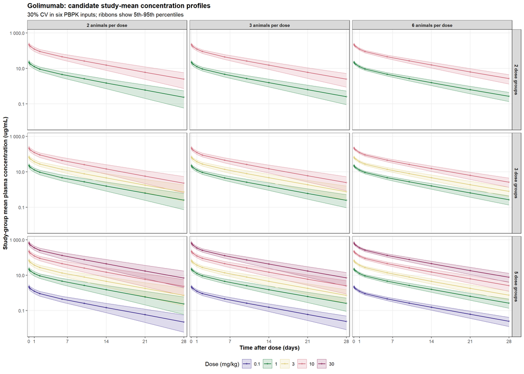

```r
plots[["Golimumab 30%"]]
```

## Golimumab: 50% input variability

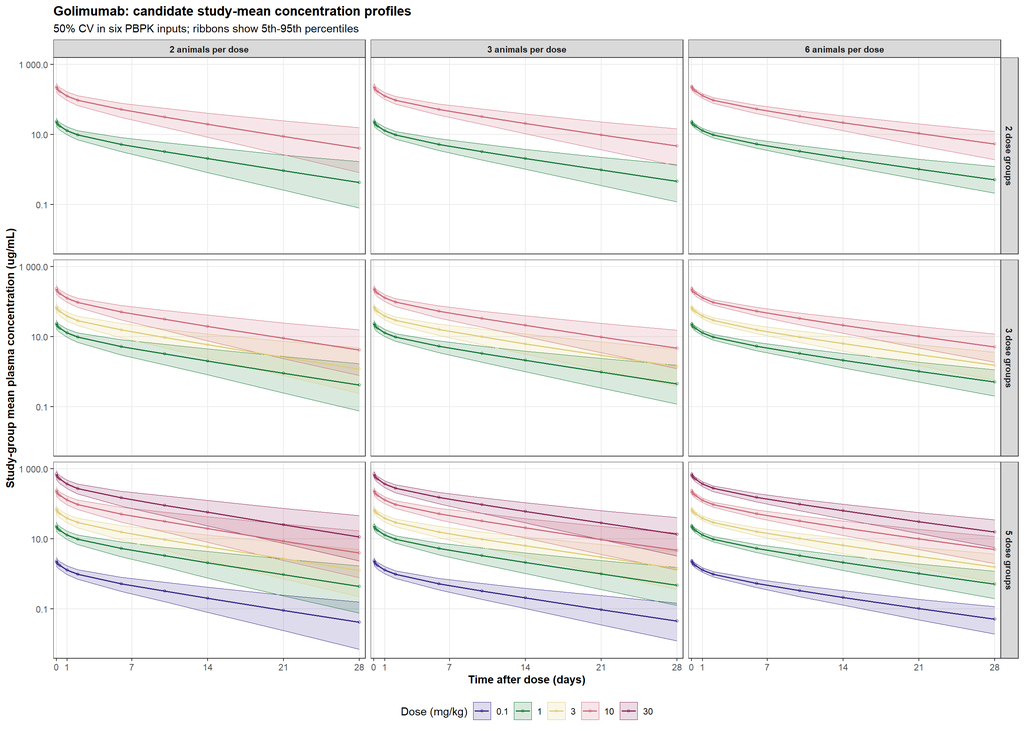

```r
plots[["Golimumab 50%"]]
```

# Step 11 Record the outputs

The saved tables make every plotted interval available without extracting values from the figures. The simulation record retains the virtual profiles, parameter draws, configured inputs, run settings, and software versions.

```r
tibble(
  Output = c(
    "Simulation record",
    "Parameter draws",
    "Base monkey population",
    "Crossed profile index",
    "Simulation settings",
    "Resumable simulation checkpoints",
    "Failed-profile diagnostic log (only if needed)",
    "Prediction-interval plotting table",
    "Candidate-design inventory",
    "PNG figures"
  ),
  Location = c(
    OUTPUT_RDS,
    PARAMETER_DRAW_FILE,
    BASE_POPULATION_FILE,
    PROFILE_INDEX_FILE,
    SETTINGS_FILE,
    CHECKPOINT_DIR,
    FAILED_PROFILE_FILE,
    PLOT_TABLE_FILE,
    DESIGN_TABLE_FILE,
    FIGURE_DIR
  )
) |>
  kable(caption = "Step 1 outputs")
```

Step 1 outputs

| Output | Location |
| --- | --- |
| Simulation record | C:/Users/krina/Documents/Projects/PBPK_mAb_NAM_Tutorial/03_Study_Simulations/SimsOutputs/SimulationProfiles/golimumab_monkey_population_uncertainty_profiles.rds |
| Parameter draws | C:/Users/krina/Documents/Projects/PBPK_mAb_NAM_Tutorial/03_Study_Simulations/SimsOutputs/Tables/golimumab_monkey_parameter_sets.csv |
| Base monkey population | C:/Users/krina/Documents/Projects/PBPK_mAb_NAM_Tutorial/03_Study_Simulations/SimsOutputs/Tables/golimumab_base_monkey_population.csv |
| Crossed profile index | C:/Users/krina/Documents/Projects/PBPK_mAb_NAM_Tutorial/03_Study_Simulations/SimsOutputs/Tables/golimumab_crossed_profile_index.csv |
| Simulation settings | C:/Users/krina/Documents/Projects/PBPK_mAb_NAM_Tutorial/03_Study_Simulations/SimsOutputs/Tables/golimumab_monkey_simulation_settings.csv |
| Resumable simulation checkpoints | C:/Users/krina/Documents/Projects/PBPK_mAb_NAM_Tutorial/03_Study_Simulations/SimsOutputs/SimulationProfiles/Step1_Checkpoints |
| Failed-profile diagnostic log (only if needed) | C:/Users/krina/Documents/Projects/PBPK_mAb_NAM_Tutorial/03_Study_Simulations/SimsOutputs/Tables/golimumab_failed_simulation_profiles.csv |
| Prediction-interval plotting table | C:/Users/krina/Documents/Projects/PBPK_mAb_NAM_Tutorial/03_Study_Simulations/SimsOutputs/Tables/golimumab_candidate_design_prediction_intervals.csv |
| Candidate-design inventory | C:/Users/krina/Documents/Projects/PBPK_mAb_NAM_Tutorial/03_Study_Simulations/SimsOutputs/Tables/golimumab_candidate_design_inventory.csv |
| PNG figures | C:/Users/krina/Documents/Projects/PBPK_mAb_NAM_Tutorial/03_Study_Simulations/SimsOutputs/Figures/Step1_Golimumab |

```r
plot_index |>
  mutate(`Variability CV (%)` = 100 * .data$Variability_CV) |>
  select(.data$Molecule, `Variability CV (%)`, .data$Figure_file) |>
  kable(caption = "Saved candidate-design figures")
```

Saved candidate-design figures

| Molecule | Variability CV (%) | Figure_file |
| --- | --- | --- |
| Golimumab | 30 | C:/Users/krina/Documents/Projects/PBPK_mAb_NAM_Tutorial/03_Study_Simulations/SimsOutputs/Figures/Step1_Golimumab/golimumab_30pct_candidate_design_prediction_intervals.png |
| Golimumab | 50 | C:/Users/krina/Documents/Projects/PBPK_mAb_NAM_Tutorial/03_Study_Simulations/SimsOutputs/Figures/Step1_Golimumab/golimumab_50pct_candidate_design_prediction_intervals.png |

```r
clearMemory()
```